# Practical Machine Learning assignment

Yuriy Barvinchenko

January 2016

## Summary

This publication is answer for PML assignment. Main target is to build model, that can predict if physical exersize was fullfiled correctly based on sensors data. Best result was shown by random forest and all 20 testing cases were predicted correctly.

## Data source

Six young health participants were asked to perform one set of 10 repetitions of the Unilateral Dumbbell Biceps Curl in five different fashions: exactly according to the specification (Class A), throwing the elbows to the front (Class B), lifting the dumbbell only halfway (Class C), lowering the dumbbell only halfway (Class D) and throwing the hips to the front (Class E). Sensors were located on forearm, arm, belt and dumbbell. Read more: http://groupware.les.inf.puc-rio.br/har.

We read data, use training data and leave 20 test cases for some time.

Trainig dataset was splited on training/test/validation/testing in 60%/20%/20% proportion.

Cases were done in sets, called windows. Data about kurtosis, skewness, minimum, maximum, amplitude, standard deviation, varibility and average presented for each type of sensor only once per window. In 95% cases these variables contains no value or NA. So we can exclude such variables from our models.  
Final set of variables stored in tr.set dataframe.

## Predictiom models

### Tree

Let’s start with tree, they are easy to understand. I’ve built 2 tree models: with caret and rpart packages.

```r
train(classe ~ ., data = tr.set, method = "rpart")
rpart(classe ~ ., data=tr.set, method="class")
```

Classification tree built with rpart package:

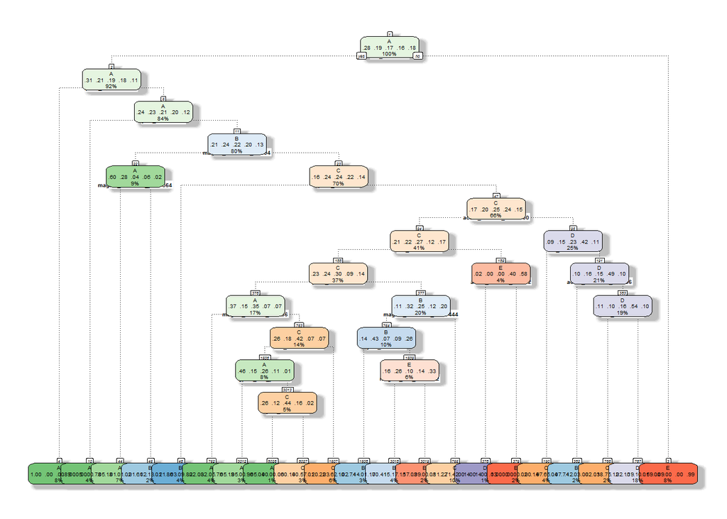

Accuracy of tree (caret) is 0.5047158 and tree (rpart) is 0.7063472, that’s pretty low.

### Random forest

I built model with 100 trees. Random forest model takes a long time, so I used parallel functionality.

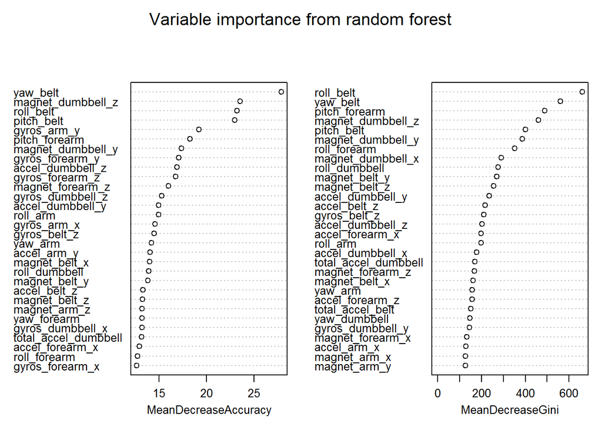

```r
randomForest(classe~.,data=tr.set,ntree=100, importance=TRUE)
```

Accuracy of random forest is 0.9910783 that is much better than for decision trees.

### Generalized Boosted Models

For GBM parallel calculation was used also. Default values were used for this model.

```r
train(classe ~ ., data = tr.set, method="gbm", trControl= fitControl, verbose=F)
```

```
## gbm variable importance
##
##   only 20 most important variables shown (out of 52)
##
##                   Overall
## roll_belt         100.000
## pitch_forearm      47.712
## yaw_belt           34.001
## magnet_dumbbell_z  30.289
## magnet_dumbbell_y  23.599
## roll_forearm       21.939
## magnet_belt_z      20.825
## roll_dumbbell      13.548
## gyros_belt_z       12.710
## accel_forearm_x    12.222
## pitch_belt         11.337
## magnet_forearm_z    9.851
## accel_dumbbell_y    9.536
## accel_dumbbell_x    8.944
## magnet_dumbbell_x   8.290
## yaw_arm             8.204
## gyros_dumbbell_y    8.040
## accel_forearm_z     7.010
## magnet_belt_y       5.465
## magnet_arm_z        5.368
```

Accuracy of GBM is 0.950803.

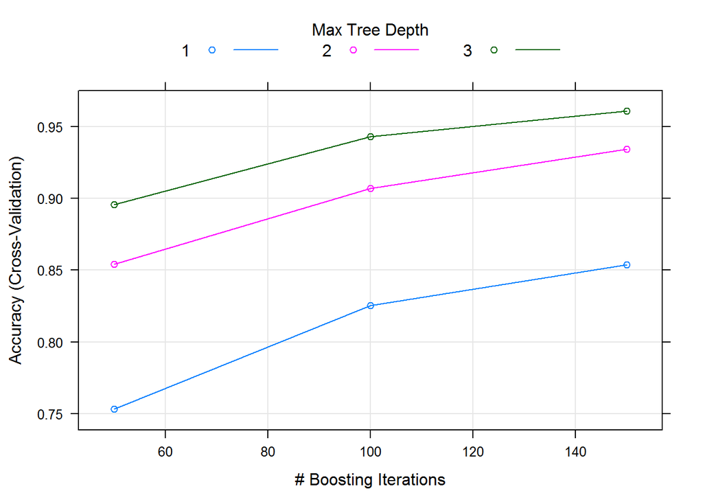

### Bagging

Default values were used for this model.

```r
train(classe ~ .,data=tr.set,method="treebag")
```

Accuracy of bagging is 0.983431.

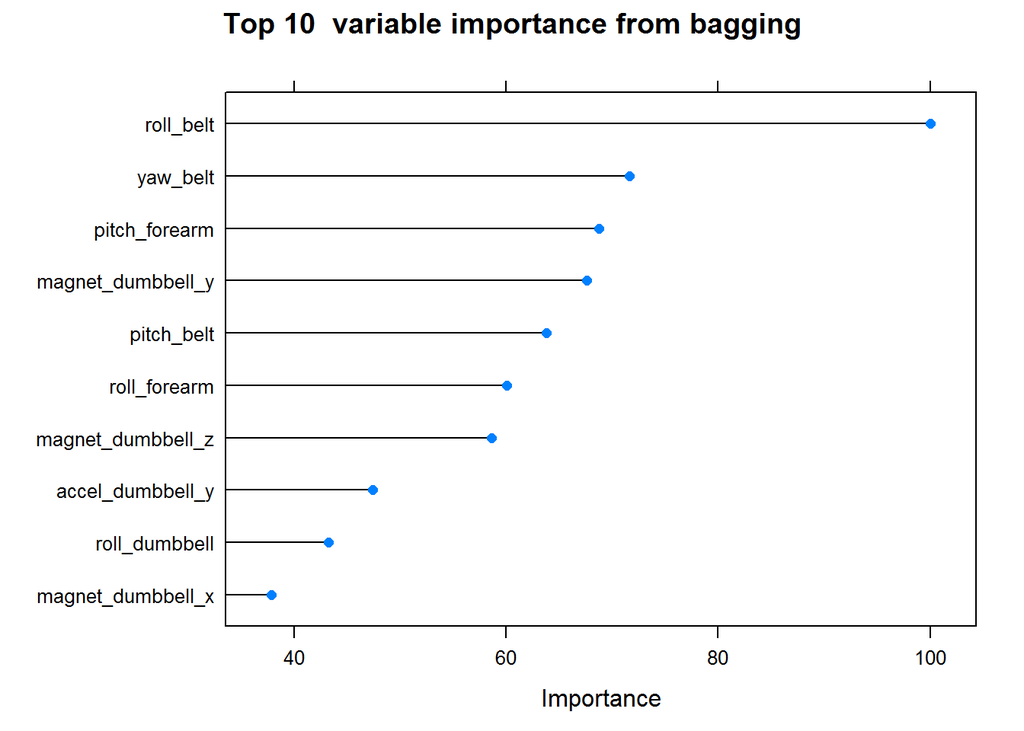

## Model selection

Trees have much lower accuracy, so to final stage cam 3 other models. Here we make double check on test and validation data.

```
## [1] "models accuracy"
```

|  | rf | GBM | bagging |
| --- | --- | --- | --- |
| test | 0.9910783 | 0.950803 | 0.9834310 |
| validation | 0.9908233 | 0.956156 | 0.9847056 |

I selected random forest with 99.1% accuracy, and second choice is bagging with 98.3-98.5%.

### Out of sample error

Out of sample error for random forest is 0.009 or 0.9% (1-0.991)

calucated with random forest

```
##  1  2  3  4  5  6  7  8  9 10 11 12 13 14 15 16 17 18 19 20
##  B  A  B  A  A  E  D  B  A  A  B  C  B  A  E  E  A  B  B  B
## Levels: A B C D E
```

P.S.Special thanks to Leonard Greski for github and parallel hints on forum